# 牛油果油真伪：一把 Codex 尺子分开三档

TidyTuesday · 2026-10-06 (Week 40)

作者

zlZayn

发布于

2026年10月28日

# 一把尺子，两张化验单

90.9%  
瓶装油「酸败或掺假」（20 / 22）

2  
瓶既纯又没过氧化（共 22 瓶）

88.9%  
标牛油果油的食品批次不合格（48 / 54）

1 / 20  
标橄榄油的食品批次不合格

六年后那 48 个不合格的「牛油果油」食品批次，C16:1 棕榈油酸的中位数是 **1.10%**，落在橄榄油的位置上。20 个橄榄油批次的区间是 0.8–2.2%，正好把这个数包住。

对照另一头，6 个真正合格的牛油果油批次全部 ≥ 4.90%。所以这些产品的问题不是「掺了一点别的油」，而是**几乎不含牛油果油**。

瓶装油那边的同一个指标分得更干脆：纯正 4.2–8.6%，掺大豆油 0.1%。6 个非纯样本全部命中，16 瓶纯正的**一个都没误伤**。

## 一、先看口径：两张表接不上

本周是两份相隔六年、彼此独立的研究合订。2020 年的瓶装油有 22 瓶；2026 年的加工食品有 74 个批次，也就是 37 个产品各测两批。口径先钉死三件事。

瓶装油的判定栏 `purity_result` 是论文结论的三档：纯正 16 瓶、疑似 3 瓶、确认掺假 3 瓶，掺假的全部是大豆油。疑似指的是谱落在正常牛油果油范围外、但还没定性。

氧化栏 `oxidized` 是另一条独立的轴：**17 瓶在保质期前已氧化，2 瓶没有**，另外 3 瓶没有读数。这 3 个空值不是缺失，说明书写明「确认是大豆油的样本，氧化状态没有意义」。两条轴交叉，既纯又没过氧化的只有 2 瓶（R3、R5）。

食品批次的 `authentic` 是策展人按 Codex 区间加 10% 容差算好的判定列，不是我重算的。标牛油果油的 54 个批次里 48 个不合格，占 88.9%。标橄榄油的 20 个批次里 1 个不合格，占 5.0%。全表不合格 66.2%。

**两张表能不能 join：不能。** 列名看似有 18 个化学指标重叠，但那是同一批检测项目，不是同一个体的两次记录。瓶装油的主键是 `sample_code`（`EV1`…），食品的主键是 `sample_number`（1–74），两者交集 0 个。

两份数据也都没有品牌 / 厂商列，匹配 `brand|manufacturer|company` 的列数是 0。所以本页不做任何跨表合并，两表只在「用同一把尺子量同一个指标」这个意义上并排阅读。

表 1: 本周两张表的口径（行数、合格与不合格的计数口径；两表不可 join，理由见正文）

| 表 | 样本单位 | 行数 | 合格口径 | 不合格口径 |
| --- | --- | --- | --- | --- |
| avocado_oil_bottles | 一瓶（2020 年 22 个零售瓶装样本） | 22 | purity_result = pure 且 oxidized = FALSE：2 行 | 掺假 3 + 疑似 3 + 已被氧化 17，占 20 行 |
| avocado_oil_processed_foods | 一个批次（37 个产品 × 2 批，2026 年） | 74 | authentic = TRUE：25 行 | authentic = FALSE：49 行（标牛油果油 48、标橄榄油 1） |

> 入图链：瓶装油 raw 22 -> plotted 22 (全部 22 瓶都进图，0 行剔除)；氧化率分母 raw 22 -> plotted 19 (3 瓶确认大豆油样本的 oxidized 为 NA（说明书写明此时氧化状态无意义）)；食品批次 raw 74 -> plotted 74 (全部 74 个批次都进图，0 行剔除)。

## 二、一把尺子量 22 瓶

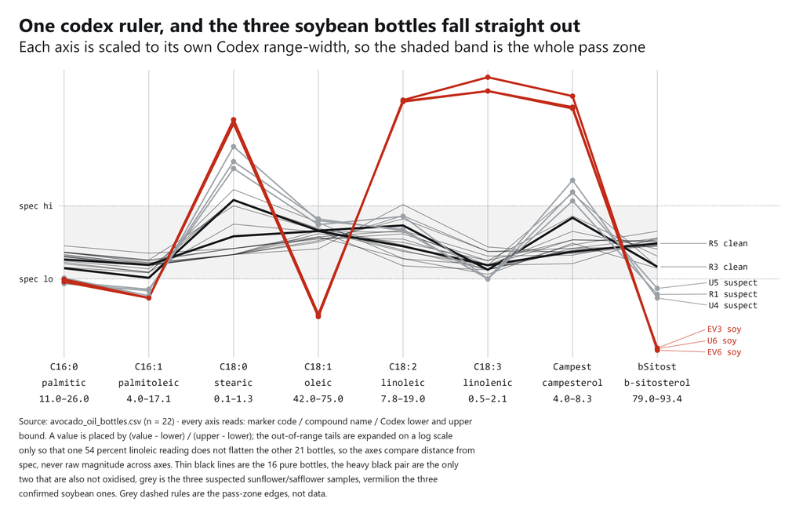

图 1: All 22 bottles on one Codex ruler: the sixteen pure samples stay inside the shaded corridor, the three soybean bottles leave it on nine to ten of thirteen markers.

**读数**：16 瓶纯正的样本**全部**落在走廊里或紧贴走廊边缘，每瓶越界 0–2 项。3 瓶确认掺大豆油的每一瓶都越界 9–10 项。3 瓶疑似落在 5–7 项。三档之间没有任何重叠，也没有一瓶纯正样本越过 5 项。

所以这条线不是「趋势」而是**分界**。3 瓶大豆油在 C16:1、C18:1、C18:2、C18:3 四条轴上一齐冲出走廊——大豆油的油酸低、亚油酸与亚麻酸高，一眼就能认。

真正值得看的是那 3 瓶「疑似」：它们的**主脂肪酸全部还在规格内**。油酸 66.5–69.1%，规格 42–75。亚油酸 15.2–17.4%，规格 7.8–19。

甾醇一侧同样越界：菜油甾醇 8.6–10.1% 双双超上限（规格上限 8.3）。

β-谷甾醇 74.7–77.0% 跌破下限（规格下限 79.0）。`adulterant` 栏把这 3 瓶写成 sunflower/safflower oil，正是这个组合指向的油种。

**这就是它们只能判「疑似」而不能判「掺假」的原因：大豆油那三条标志性脂肪酸，它们是干净的。**

不能得出的结论：这张图**不能**说「越界项数 = 掺假程度」。图里只有 22 瓶，且 `purity_result` 是论文的人工判定，越界项数与判定的一致性是我事后对照出来的，不是因果；也不能反过来说「越界 2 项就没事」——2 瓶真合格样本（R3、R5）里就有一瓶仍有 2 项越界。

表 2: 图 1 的原始数字（22 瓶全列；「已氧化」的「无读数」= 确认大豆油样本，说明书写明此时氧化状态无意义）

| 样本 | 标签等级 | 判定 | 已氧化 | C16:1 % | C18:2 % | C18:3 % | 菜油甾醇 % | β-谷甾醇 % |
| --- | --- | --- | --- | --- | --- | --- | --- | --- |
| EV3 | extra virgin | adulterated | 无读数 | 0.1 | 54.4 | 8.2 | 20.3 | 56.3 |
| EV6 | extra virgin | adulterated | 无读数 | 0.1 | 55.4 | 9.8 | 23.3 | 55.2 |
| U6 | unspecified | adulterated | 无读数 | 0.1 | 54.7 | 8.2 | 20.6 | 56.0 |
| R1 | refined | suspected | 是 | 1.7 | 15.2 | 0.5 | 8.6 | 75.6 |
| U4 | unspecified | suspected | 是 | 2.0 | 17.4 | 0.5 | 10.1 | 74.7 |
| U5 | unspecified | suspected | 是 | 0.6 | 15.4 | 0.5 | 9.2 | 77.0 |
| EV1 | extra virgin | pure | 是 | 6.9 | 19.2 | 1.2 | 5.5 | 85.6 |
| EV2 | extra virgin | pure | 是 | 6.5 | 15.2 | 1.0 | 5.4 | 86.8 |
| EV4 | extra virgin | pure | 是 | 6.4 | 17.0 | 1.1 | 5.6 | 86.0 |
| EV5 | extra virgin | pure | 是 | 6.4 | 17.5 | 1.1 | 5.8 | 85.4 |
| EV7 | extra virgin | pure | 是 | 6.6 | 13.4 | 0.9 | 6.3 | 86.3 |
| R2 | refined | pure | 是 | 5.8 | 12.2 | 0.7 | 5.7 | 85.7 |
| R3 | refined | pure | 否 | 4.2 | 16.0 | 0.7 | 7.6 | 81.4 |
| R4 | refined | pure | 是 | 6.8 | 12.0 | 0.8 | 4.9 | 87.1 |
| R5 | refined | pure | 否 | 6.5 | 12.8 | 0.8 | 5.6 | 86.0 |
| R6 | refined | pure | 是 | 8.6 | 10.9 | 0.8 | 6.3 | 86.5 |
| R7 | refined | pure | 是 | 5.2 | 13.0 | 0.7 | 5.8 | 87.0 |
| R8 | refined | pure | 是 | 5.1 | 10.9 | 0.6 | 6.1 | 81.1 |
| R9 | refined | pure | 是 | 5.2 | 15.0 | 0.8 | 9.1 | 81.4 |
| U1 | unspecified | pure | 是 | 7.4 | 9.8 | 0.7 | 6.0 | 88.4 |
| U2 | unspecified | pure | 是 | 7.2 | 14.7 | 0.9 | 7.7 | 83.5 |
| U3 | unspecified | pure | 是 | 7.4 | 13.9 | 0.8 | 6.8 | 84.9 |

## 三、六项全中，但硬脂酸误伤四瓶纯正样本

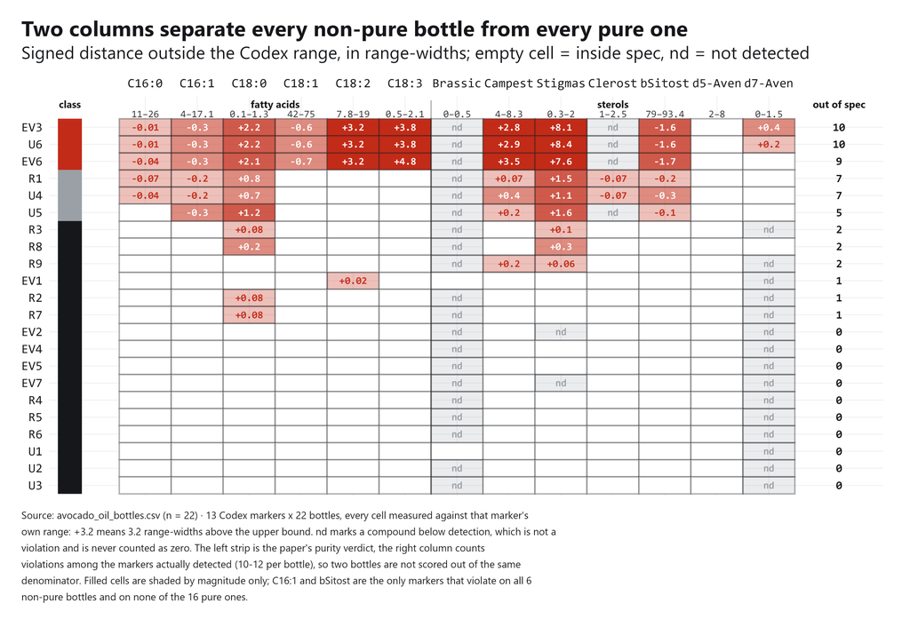

图 2: Nine to ten of thirteen markers move at once on each soybean bottle, five to seven on each suspected one, and at most two on any pure bottle.

**读数**：13 项规格，每瓶实际检出 10–12 项。**只有 C16:1 与 bSitost 两条指标做到「6 个非纯全中、16 瓶纯正零误伤」。**

C16:1 最干脆。纯正 4.2–8.6%。疑似 0.6–2.0%，掺假那一档只有 0.1%。

三档之间没有任何重叠。β-谷甾醇次之，纯正最低 81.1%、掺假最高 56.3%。

反倒是几条常被当作「掺假指纹」的指标会误伤。C18:0 硬脂酸把 4 瓶纯正样本也标成越界，豆甾醇误伤 3 瓶，菜油甾醇误伤 1 瓶。

**所以看单一指标会被假阳性带偏，看越界项数才稳。** 3 瓶大豆油越界 9–10 项。16 瓶纯正只越界 0–2 项，两档之间的空隙比任何单一指标都宽。

不能得出的结论：`nd`（未检出）的格子**不是 0**，它只是「低于检出限」，所以每瓶的分母不同。正文只比「几项」不比「占几成」，不能拿 10/13 和 9/11 直接比大小。这也是我没有把 `total_sterols_mg_kg` 放进尺子的原因：readme 没给它区间，硬编一个阈值就成了自定标准。

表 3: 图 2 的列合计（每项在 22 瓶里检出几瓶、越界几瓶；「越界比例」的分母是检出样本数，不是 22）

| 指标 | 族 | 检出样本数 | 越界样本数 | 越界比例 |
| --- | --- | --- | --- | --- |
| C18:0 | fatty acid | 22 | 10 | 45.5% |
| Stigmas | sterol | 20 | 9 | 45.0% |
| Campest | sterol | 22 | 7 | 31.8% |
| C16:1 | fatty acid | 22 | 6 | 27.3% |
| bSitost | sterol | 22 | 6 | 27.3% |
| C16:0 | fatty acid | 22 | 5 | 22.7% |
| C18:2 | fatty acid | 22 | 4 | 18.2% |
| C18:1 | fatty acid | 22 | 3 | 13.6% |
| C18:3 | fatty acid | 22 | 3 | 13.6% |
| Clerost | sterol | 18 | 2 | 11.1% |
| d7-Aven | sterol | 7 | 2 | 28.6% |
| Brassic | sterol | 2 | 0 | 0.0% |
| d5-Aven | sterol | 22 | 0 | 0.0% |

## 四、六年后，食品批次落在橄榄油的位置

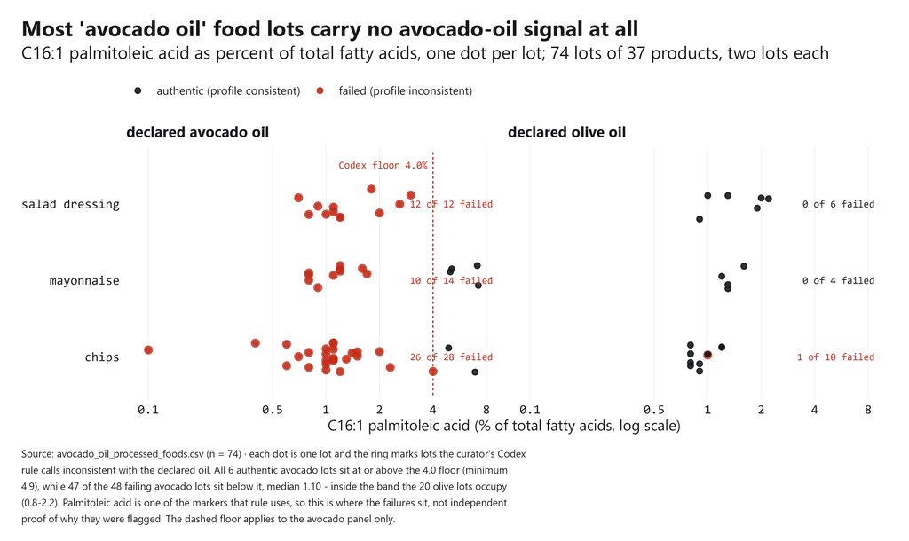

图 3: Under the avocado-oil label, the failing lots sit exactly where olive oil sits; only six avocado lots clear the 4.0 percent palmitoleic floor.

**读数**：6 个合格的牛油果油批次**全部**在 4.0 线上或以上，最低 4.9。

另一头，48 个不合格批次里有 47 个跌破这条线，中位数只有 1.10。这个数正好落在 20 个橄榄油批次所在的 0.8–2.2 区间里。

橄榄油那一侧 20 个批次只有 1 个不合格，是一个标 Olive Oil 的薯片批次。

所以本周真正的对照不是「牛油果油 vs 橄榄油」，而是「有监管的品类 vs 没监管的品类」。**同一条 Codex 尺子、同一批实验室、同一个年份**，橄榄油 5% 不合格，牛油果油 89% 不合格。

不能得出的结论：**不能**说这些产品「掺了大豆油」。掺大豆油会把 C18:2 亚油酸推到 50% 以上（瓶装油那 3 瓶就是 54–55%），而这里的失败批次 C18:2 中位数只有 16.1%，差着一个量级。数据只能说到「这些批次的指纹与它声明的油种不符」，具体换成了哪一种油、换了几成，这两张表都答不了。

表 4: 图 3 的原始数字（按声明油种 × 品类；「C16:1 区间」是该组全部批次的最小–最大）

| 声明油种 | 品类 | 批次数 | 不合格 | 不合格率 | C16:1 中位数 | C16:1 区间 |
| --- | --- | --- | --- | --- | --- | --- |
| declared avocado oil | chips | 28 | 26 | 92.9% | 1.10 | 0.1–6.9 |
| declared avocado oil | mayonnaise | 14 | 10 | 71.4% | 1.20 | 0.8–7.2 |
| declared avocado oil | salad dressing | 12 | 12 | 100.0% | 1.15 | 0.7–3.0 |
| declared olive oil | chips | 10 | 1 | 10.0% | 0.90 | 0.8–1.2 |
| declared olive oil | mayonnaise | 4 | 0 | 0.0% | 1.30 | 1.2–1.6 |
| declared olive oil | salad dressing | 6 | 0 | 0.0% | 1.60 | 0.9–2.2 |

## 五、氧化和纯度互不相干

**氧化和纯度几乎不相关。** 在 22 瓶里，17 瓶在保质期前已氧化。按有读数的 19 瓶算，氧化率是 89.5%。

纯正组 14/16 氧化。疑似组 3/3 氧化。掺假不掺假，该氧化的还是氧化了，两条轴交叉后只剩 2 瓶过关。

**价格也不区分真伪。** 22 瓶的价格带是 $0.25–2.35 每液量盎司，跨度接近 10 倍。

但掺大豆油的 3 瓶全在 $0.34–$0.65。真合格的 2 瓶则落在 $0.25–$0.43，两头挤在同一个低价区间。

最贵的两瓶（$2.23、$2.35，都是 extra virgin）确实纯正，可纯正组从 $0.25 一路铺到 $2.35。换言之：**贵的不一定假，但便宜的两头都有**。

n = 22 且是 2020 年一次采购的快照，这条只能当描述，不能外推成「价格与真伪无关」的结论。

表 5: 氧化 × 纯度交叉表（22 瓶全列；「no reading」= 3 瓶确认大豆油样本，说明书写明此时氧化状态无意义，不是缺失）

| 判定 | oxidised | not oxidised | no reading |
| --- | --- | --- | --- |
| pure | 14 | 2 | 0 |
| suspected | 3 | 0 | 0 |
| adulterated | 0 | 0 | 3 |

表 6: 价格分布（美元 / 液量盎司）按纯度判定分组；三组区间互相覆盖，没有一档单靠价格可分离

| 判定 | 瓶数 | 最低价 | 中位价 | 最高价 |
| --- | --- | --- | --- | --- |
| adulterated | 3 | 0.34 | 0.49 | 0.65 |
| suspected | 3 | 0.44 | 0.47 | 0.79 |
| pure | 16 | 0.25 | 0.76 | 2.35 |

## 数据异常（记录，不改数据）

| 现象 | 原始数字 | 处理 |
| --- | --- | --- |
| 「氧化」计数与引言口径不一致 | 引言与清洗脚本注释都写「15 只样本在保质期前氧化」，但列里 `oxidized = TRUE` 是 **17** 瓶（14 瓶纯正 + 3 瓶疑似）；按引言口径「酸败或掺假」= 18/22（81.8%），按列算是 **20/22（90.9%）** | 不改数。正文与 KPI 一律用列口径并注明「按列重算」，不引用引言那个百分比 |
| `oxidized` 的 3 个空值不是缺失 | EV3、EV6、U6 三瓶确认大豆油样本全为 `NA` | 说明书写明此时氧化状态无意义；氧化率分母取 19 瓶而非 22 瓶，图 1 里这三瓶单独用灰红区分 |
| `grade_labeled` 是派生列 | 由 `sample_code` 前缀（EV / R / U）反推，不是瓶上另记的字段 | 保留原值但不当作独立证据：3 瓶掺假里有 2 瓶标着 extra virgin |
| 食品表 6 列整列为空 | `c6_0_pct`、`c8_0_pct`、`c10_0_pct`、`c20_2_pct`、`c24_1_pct`（读成 logical，全 `NA`）、`c12_0_pct`（double，全 `NA`）—— 74/74 缺失 | 一律不用、也不当 0：既可能是「未检出」也可能是「未检测」，两表之间无法区分 |
| 食品表甾醇列大面积缺失 | `apparent_beta_sitosterol_pct` 缺 54/74、`c14_0_pct` 缺 53/74、`brassicasterol_pct` 缺 52/74、`c17_0_pct` 缺 47/74 | 不插补。缺得少的列照用，缺过半的列不进任何图，只在表里出现 |
| `authentic` 是派生列，不是实测 | 由脂肪酸 + 甾醇指纹按 Codex 区间（10% 容差）算出的判定 | 直接引用策展人的列；图 3 的 C16:1 本身就在那条规则里，因此图 3 的读数**不是独立验证**，正文已写明 |
| 两张表无法 join | 共享主键 0 个；`sample_code`（EV1…）与 `sample_number`（1–74）无交集；两表均无品牌列 | 不合并、不假设「同一品牌」。跨表只做「同一把尺子量同一指标」的并排，不做逐产品追溯 |
| 产地不是单值 | `product_origin` 有「Mexico, USA, or Spain」（3 瓶）、「Spain or Mexico」（1 瓶）这类多值标签 | 不按产地聚合；产地只在表里出现 |
| 保质期是字符串 | `expiration_date` 形如 `Oct-21`（按月、无日），且 2 瓶为空 | 不转日期、不参与任何时间轴；本页不用它 |
| 食品表有混合声明 | 20 个橄榄油批次里有 2 个声明「Refined Olive Pomace Oil, Extra Virgin Olive Oil」 | `oil_type` 一律按策展人的 olive；不把油渣油拆出来单算 |
| 样本量太小，不能外推 | 瓶装 22 瓶；食品 74 个批次 = 37 个产品，单组最少只有 4 个批次 | 全页不做回归、不做分类器、不报 p 值；所有比较是逐样本 / 逐组计数，结论自带「在这 22 瓶 / 这 74 个批次里」的限定 |

## 方法与口径

[output not shown]